# Explore IOS Apps Reviews

In this example we have extracted the FaceBook App reviews from Itunes.

#### Rating trends across the last few months

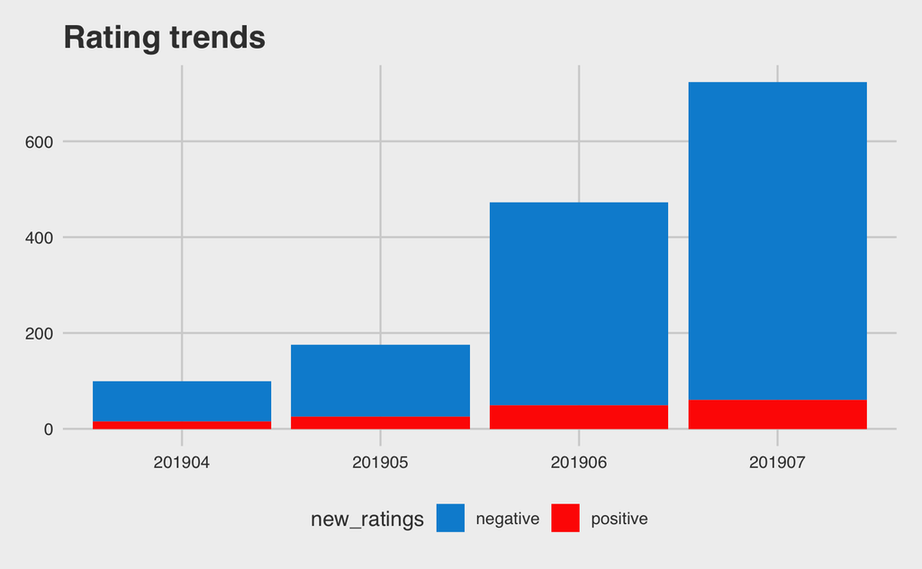

#### What is the market wise sentiment?

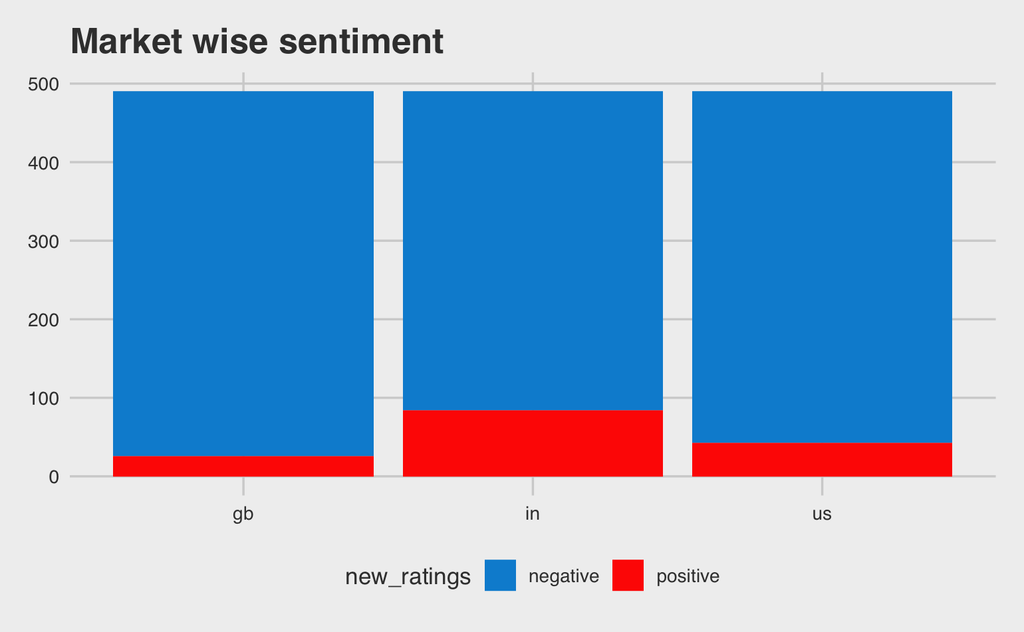

- India shows more positive trends compared with US & GB

#### Trend of actual ratings across the months/markets

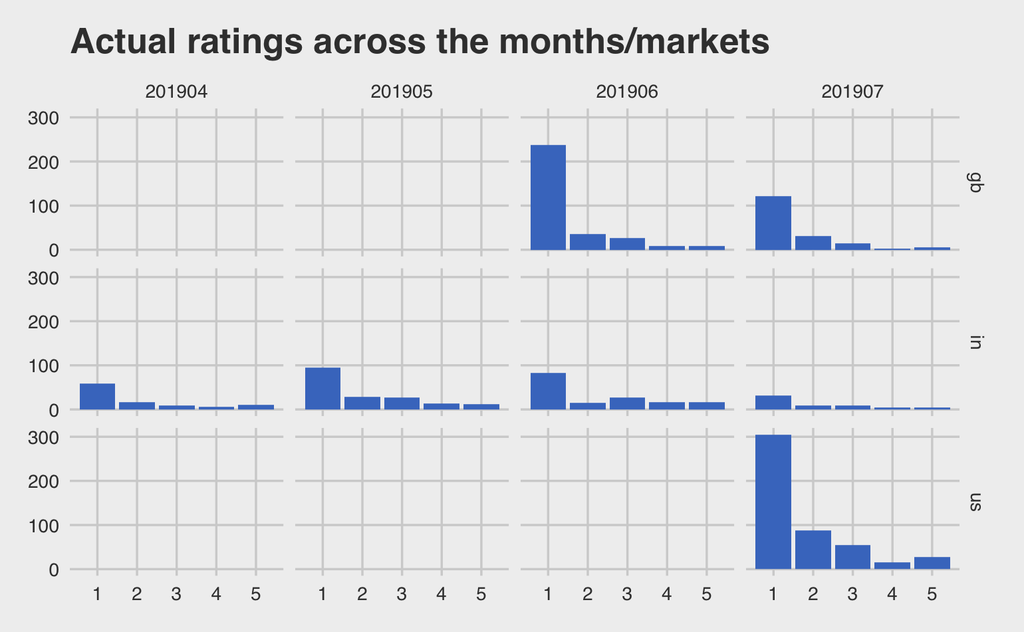

- We do not have a very good spread of data since US has maximum reviews in last month itself while countries like IN have it spread over last few months.

#### Trend of actual ratings across the months/app versions

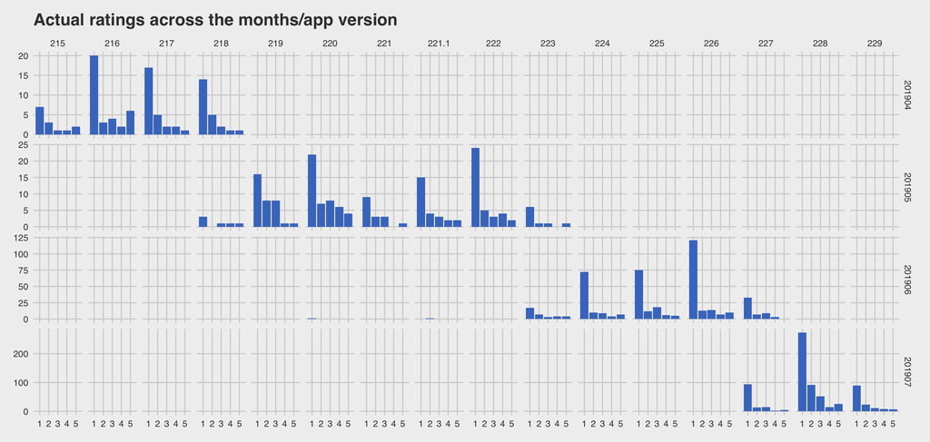

- We can see that certain app versions spiked in their negative ratings. We will check on this fact during the sentiment analysis on the comments.

#### Trend of actual ratings across the app versions/markets

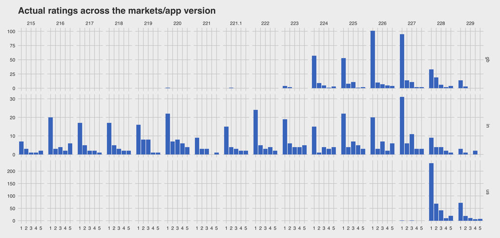

- We see that due to the data extract where certain markets have higher review counts compared with others, the app versions are not linear. US/GB have high reviews in last 1-2 months hence we have data only for the latest few app versions.

Lets process the review texts and do some sentiment analysis via natural language processing(NLP)

#### Polarity analysis by positive/negative sentiment

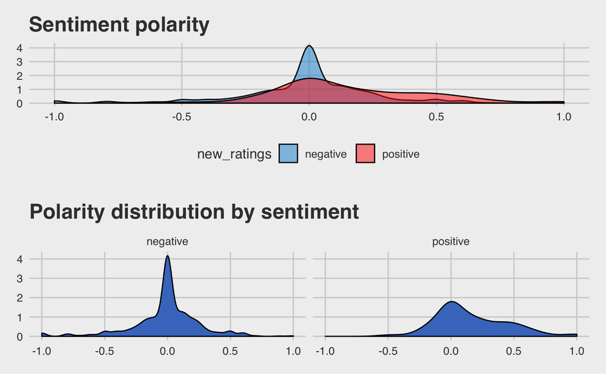

#### Sentiment distribution

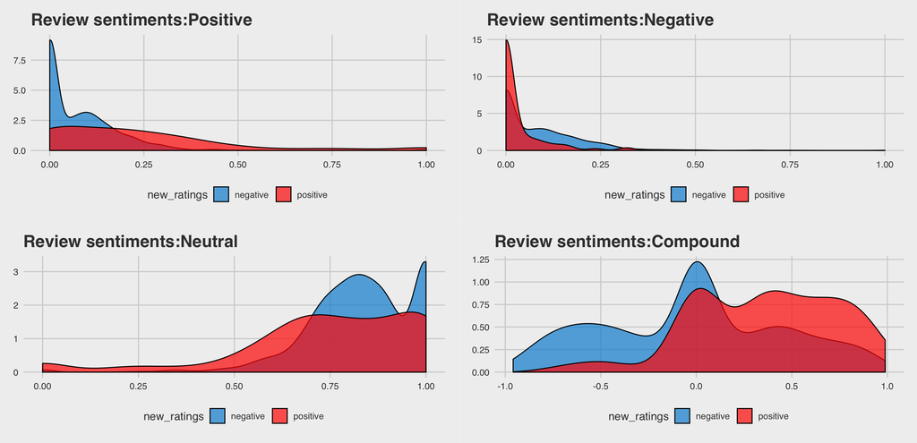

#### Sentiment analysis on the review text per ratings

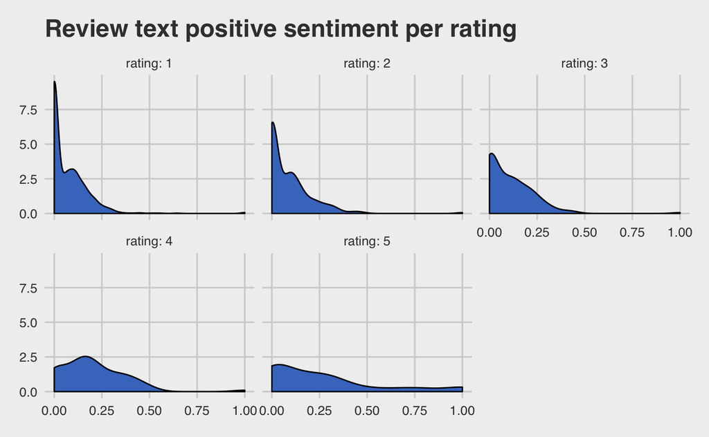

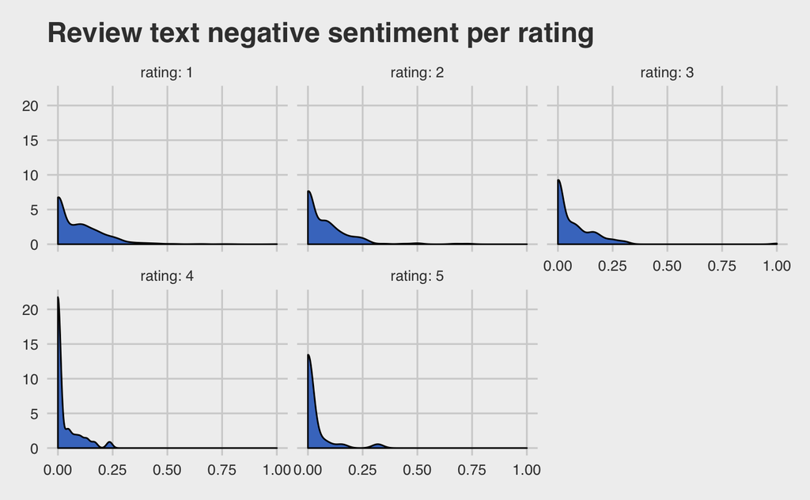

- Users giving ratings=1&2 show high usage of negative sentiments.

#### Sentiment analysis on the review text per market

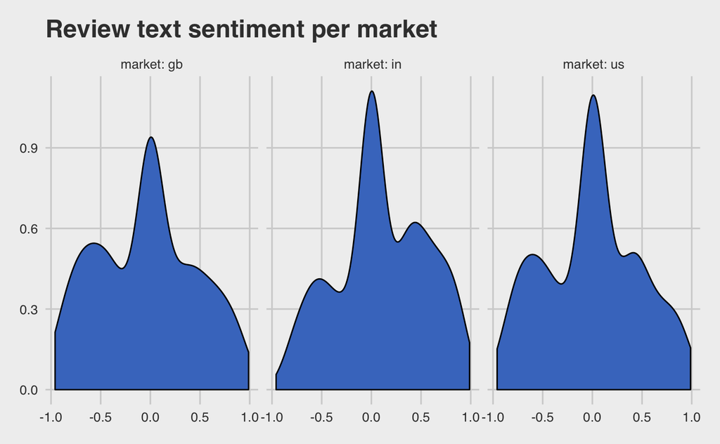

- Indians tend to be positive in their overall sentiments. UK/US tends to be more negative.

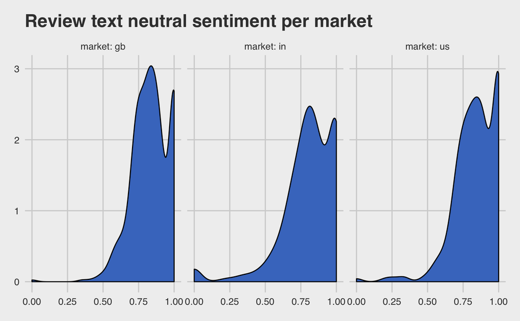

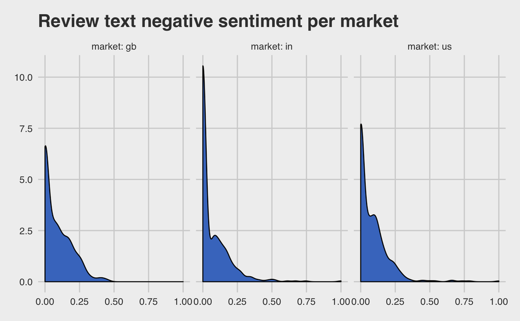

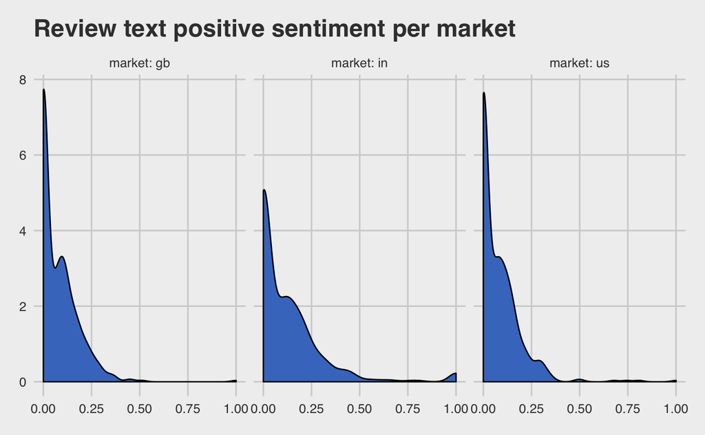

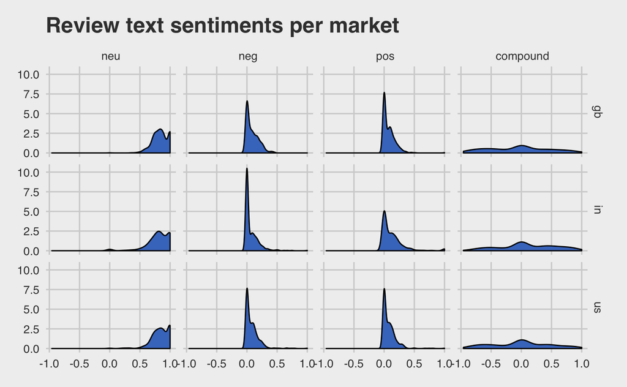

#### What are the string lengths of the reviews per rating, markets?

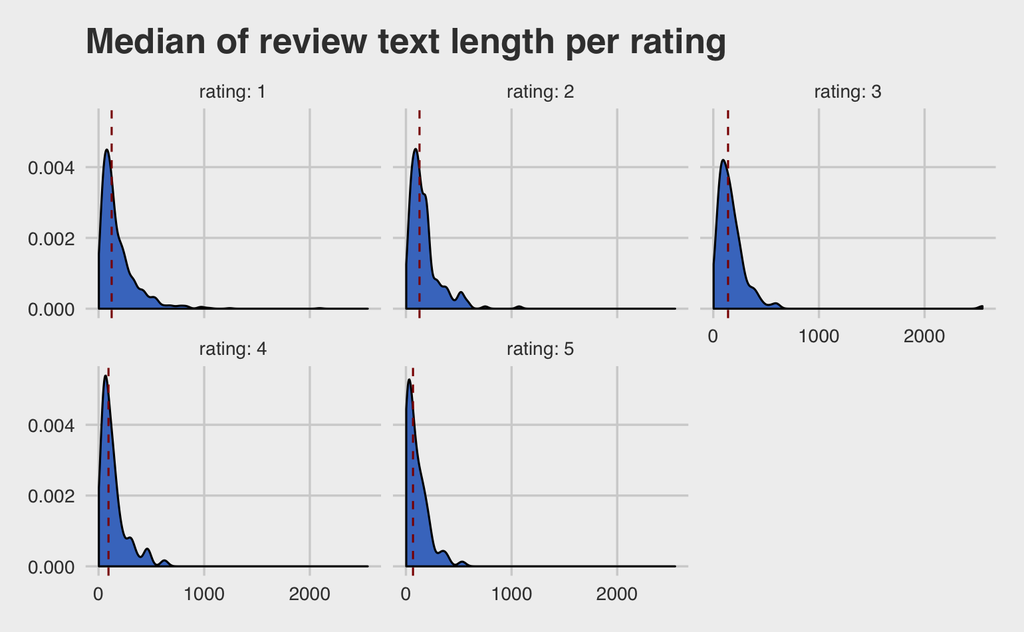

- As expected, positive reviews have less average review lengths compared to negative review.. We do like to rant i guess !

#### Median of review lengths per ratings

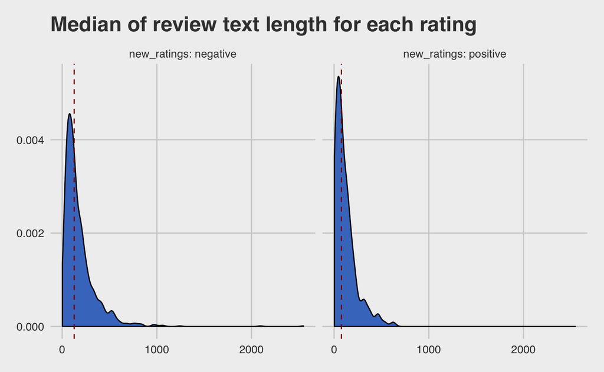

- People write more for negative review as compared to positive

#### Median of review lengths per market

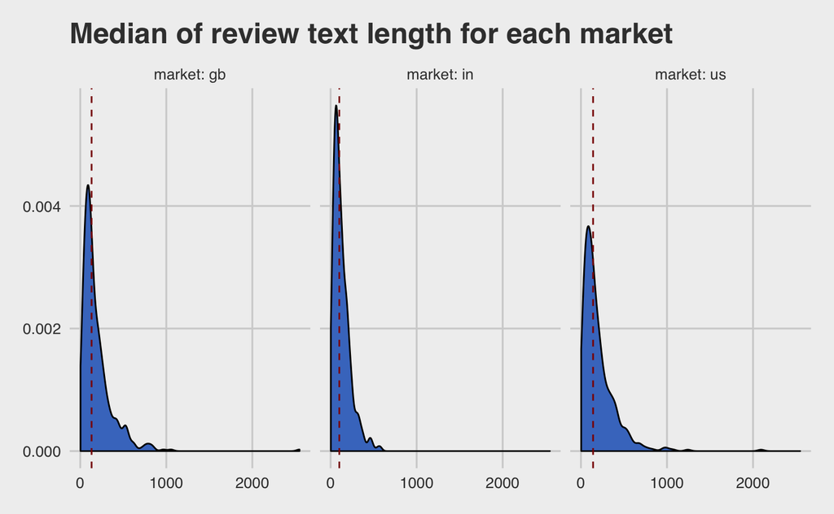

- Americans write more in general as compared with IN & GB. There are few outliners having >1000 text lengths, we will have to review those to see if they are valid or rantings!